# Analysis of Longitudinal Data

The last chapter of this IODS course will focus on analysis of longitudinal data. Contrary to the previous chapters, in this chapter, the data that we explore will have observations that correlate with each others. This dependency introduces another challenge for predictive models. Now, we have multiple observations of the same individuals (e.g., repeated measures over time). To overcome this challenge, we will study a class of methods, the **linear mixed effect** models. We consider two different models: the **random intercept model** and the **random intercept and slope model**.

**Task 1: Data Wrangling**

Done, and can be found [here](https://github.com/teemuvh/IODS-project/blob/master/data/meet_and_repeat.R).

**Task 2: Analysis**

**Task a:**

In this exercise, I attempt at replicating the analysis in the course material (chapter 8 of Vehkalahti & Everitt, 2019) using the *rats* data. This data consists of a set of longitudinal observations of 16 rats representing their body weights (in grams) over a 9-week period. Each rat is assigned into a group (1–3) and is identified by their id (1–16). The observations are their body weights. The data was transformed into a long form table in the data wrangling exercise, so it is already ready for further analysis.

```r
library(dplyr)
RATS <- read.table("data/ratsl.txt", sep = ",", header = T)

RATS$ID <- factor(RATS$ID)
RATS$Group <- factor(RATS$Group)

glimpse(RATS)
```

```
## Rows: 176
## Columns: 5
## $ ID     <fct> 1, 2, 3, 4, 5, 6, 7, 8, 9, 10, 11, 12, 13, 14, 15, 16, 1, 2, 3,…
## $ Group  <fct> 1, 1, 1, 1, 1, 1, 1, 1, 2, 2, 2, 2, 3, 3, 3, 3, 1, 1, 1, 1, 1, …
## $ WD     <chr> "WD1", "WD1", "WD1", "WD1", "WD1", "WD1", "WD1", "WD1", "WD1", …
## $ Weight <int> 240, 225, 245, 260, 255, 260, 275, 245, 410, 405, 445, 555, 470…
## $ Time   <int> 1, 1, 1, 1, 1, 1, 1, 1, 1, 1, 1, 1, 1, 1, 1, 1, 8, 8, 8, 8, 8, …
```

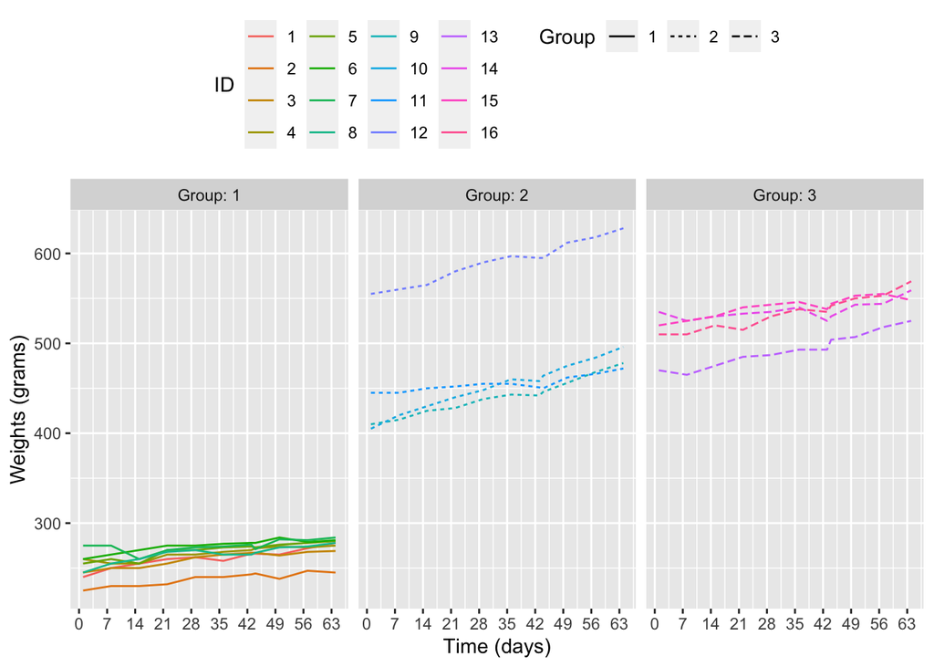

```r
#Access the package ggplot2
library(ggplot2)
library(dplyr)
library(tidyr)

# Plot RATS data by group
library(ggplot2)
ggplot(RATS, aes(x = Time, y = Weight, linetype = Group, col = ID)) +
  geom_line() +
  scale_x_continuous(limits = c(min(RATS$Time), max(RATS$Time)), name = "Time (days)", breaks = seq(0, 64, 7)) +
  facet_grid(. ~ Group, labeller = label_both) +
  scale_y_continuous(name = "Weights (grams)") +
  theme(legend.position = "top")
```

Above, I plot the visualizations so that it would be rather easy to assess the difference in weights every one week in each group and each individual. We can observe a slight increasing trend in all of the groups. Next, I standardize the weights to see if that helps in visualizing the phenomenon.

```r
RATS_std <- RATS %>%
  group_by(ID) %>%
  mutate(stdweight = (Weight - mean(Weight))/sd(Weight)) %>%
  ungroup()

glimpse(RATS)
```

```
## Rows: 176
## Columns: 5
## $ ID     <fct> 1, 2, 3, 4, 5, 6, 7, 8, 9, 10, 11, 12, 13, 14, 15, 16, 1, 2, 3,…
## $ Group  <fct> 1, 1, 1, 1, 1, 1, 1, 1, 2, 2, 2, 2, 3, 3, 3, 3, 1, 1, 1, 1, 1, …
## $ WD     <chr> "WD1", "WD1", "WD1", "WD1", "WD1", "WD1", "WD1", "WD1", "WD1", …
## $ Weight <int> 240, 225, 245, 260, 255, 260, 275, 245, 410, 405, 445, 555, 470…
## $ Time   <int> 1, 1, 1, 1, 1, 1, 1, 1, 1, 1, 1, 1, 1, 1, 1, 1, 8, 8, 8, 8, 8, …
```

```r
glimpse(RATS_std)
```

```
## Rows: 176
## Columns: 6
## $ ID        <fct> 1, 2, 3, 4, 5, 6, 7, 8, 9, 10, 11, 12, 13, 14, 15, 16, 1, 2,…
## $ Group     <fct> 1, 1, 1, 1, 1, 1, 1, 1, 2, 2, 2, 2, 3, 3, 3, 3, 1, 1, 1, 1, …
## $ WD        <chr> "WD1", "WD1", "WD1", "WD1", "WD1", "WD1", "WD1", "WD1", "WD1…
## $ Weight    <int> 240, 225, 245, 260, 255, 260, 275, 245, 410, 405, 445, 555, …
## $ Time      <int> 1, 1, 1, 1, 1, 1, 1, 1, 1, 1, 1, 1, 1, 1, 1, 1, 8, 8, 8, 8, …
## $ stdweight <dbl> -2.02487690, -1.73484555, -1.76767584, -0.90187616, -1.63589…
```

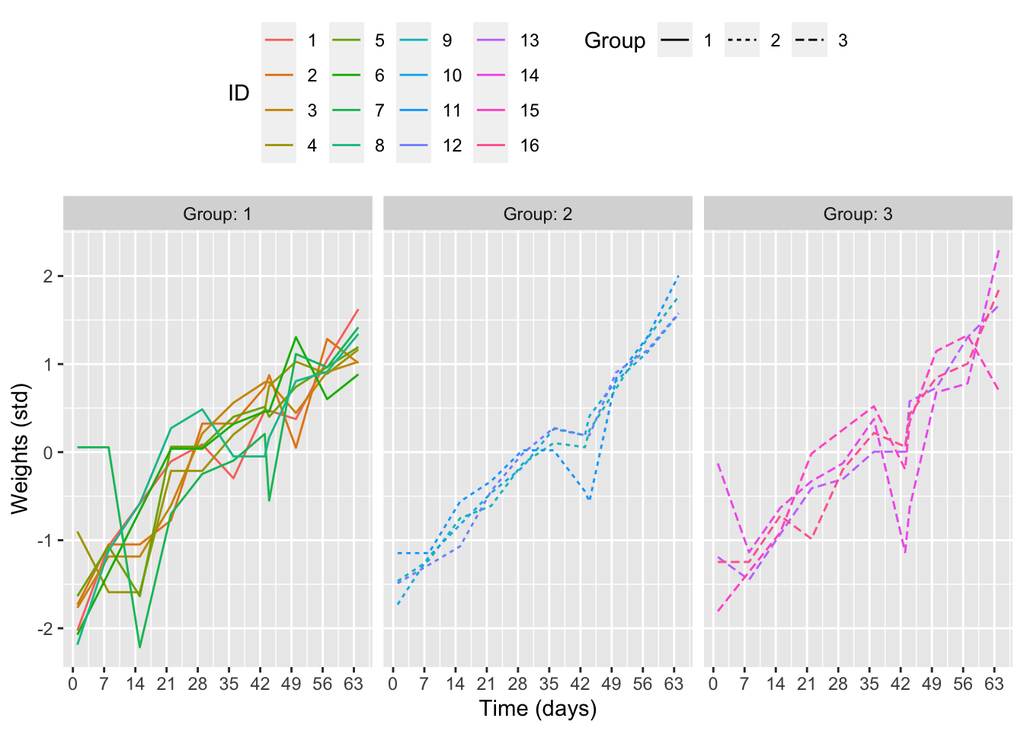

```r
library(ggplot2)
ggplot(RATS_std, aes(x = Time, y = stdweight, linetype = Group, col = ID)) +
  geom_line() +
  scale_x_continuous(name = "Time (days)", breaks = seq(0, 64, 7)) +
  facet_grid(. ~ Group, labeller = label_both) +
  scale_y_continuous(name = "Weights (std)") +
  theme(legend.position = "top")
```

After standardizing the data, we can see the increase in the observed weights easier.

The next step is to provide a graph that shows a summary measure of the longitudinal data. Here, the weights of each individual in each time point are transformed into a single value, that can reveal interesting features of the measure over time. First, I group the data by the groups of the individuals (1–3), and present a box plot of the mean weights of the different groups beginning from the first time point (time > 0). This will transform the data of 176 observations (16 individuals and 11 time points) to 16 observations (mean of the weights of the individuals), one for each individual. From the first box plot, we can see that there are some outliers in the mean weight data. The outlier in the second group seems to be especially far from the IQR, and, thus, I remove it from the data. I decided to leave the other groups as they are.

```r
library(dplyr)
library(tidyr)
# Create a summary data by treatment and subject with mean as the summary variable (ignoring baseline week 0)
RATSS <- RATS %>%
  filter(Time > 0) %>%
  group_by(Group, ID) %>%
  summarise( mean=mean(Weight) ) %>%
  ungroup()
```

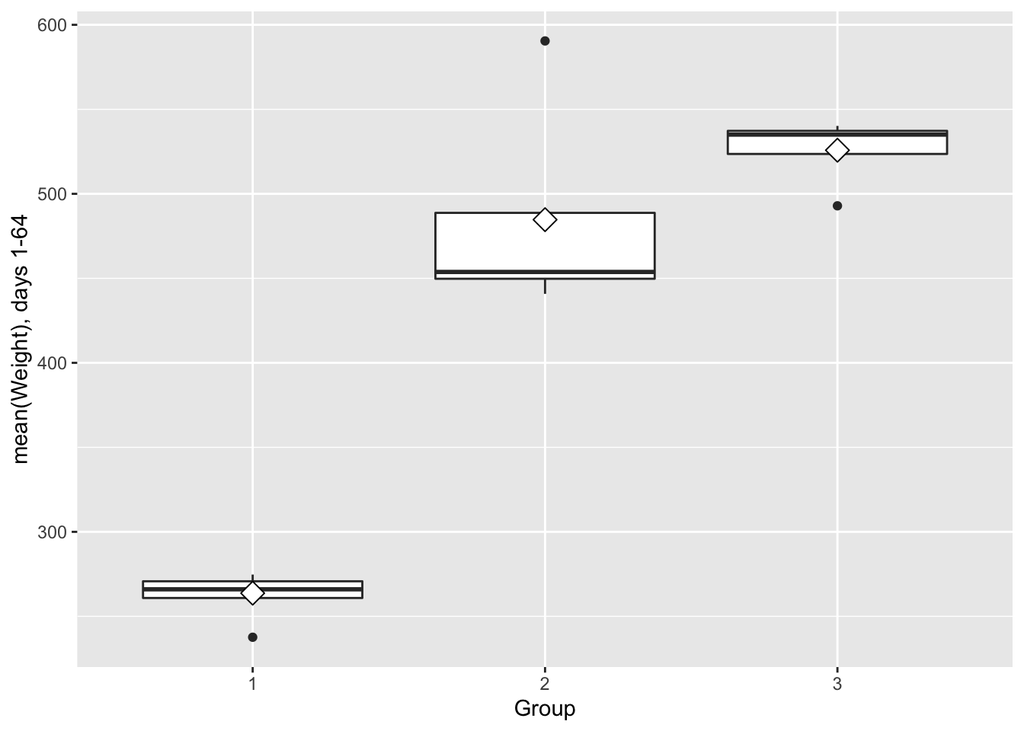

```r
# Draw a boxplot of the mean versus treatment
library(ggplot2)
ggplot(RATSS, aes(x = Group, y = mean)) +
  geom_boxplot() +
  stat_summary(fun = "mean", geom = "point", shape=23, size=4, fill = "white") +
  scale_y_continuous(name = "mean(Weight), days 1-64")
```

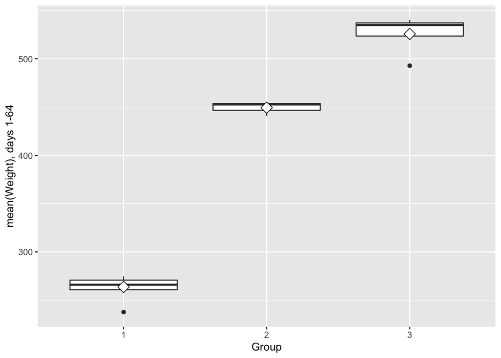

```r
# Create a new data by filtering the outlier and adjust the ggplot code then draw the plot again with the new data
RATSS1 <- RATSS %>%
  filter(mean < 580)

library(ggplot2)
ggplot(RATSS1, aes(x = Group, y = mean)) +
  geom_boxplot() +
  stat_summary(fun = "mean", geom = "point", shape=23, size=4, fill = "white") +
  scale_y_continuous(name = "mean(Weight), days 1-64")
```

Next, I attempt to visualize the means response profiles of the groups over time. This figure (below) represents the variation of the observations in each time point of the experiment. We can notice that there is only very little variation in groups 1 and 3, but a slightly more variation in group 2. Additionally, we notice, again, a slight increase in weights over time.

```r
# Number of subjects (per group):
n <- 11

library(dplyr)
library(tidyr)
# Summary data with mean and standard error of Weight by Group and Time
RATSS2 <- RATS %>%
  group_by(Group, Time) %>%
  summarise( mean = mean(Weight), se = sd(Weight)/sqrt(n) ) %>%
  ungroup()
```

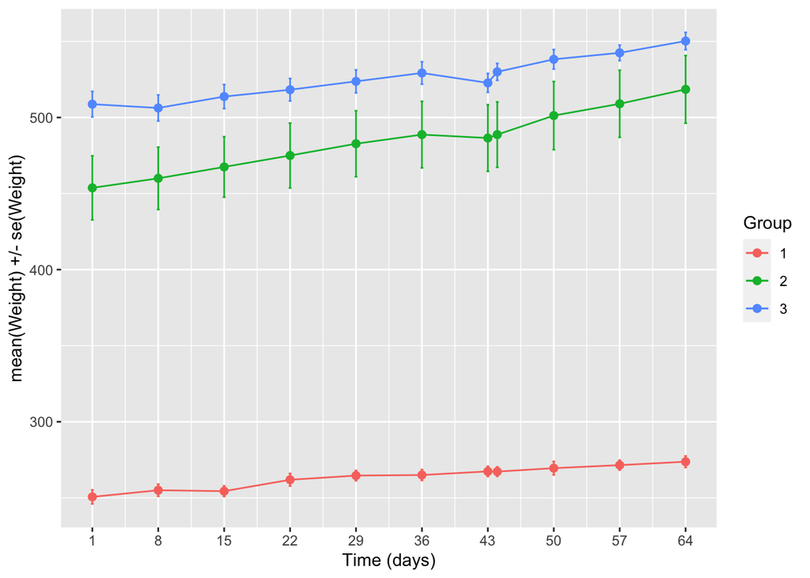

```r
# Plot the mean profiles
library(ggplot2)
ggplot(RATSS2, aes(x = Time, y = mean, col = Group)) +
  geom_line() +
  geom_point(size=2) +
  geom_errorbar(aes(ymin=mean-se, ymax=mean+se), width=0.3) +
  theme(legend.position = "right") +
  scale_y_continuous(name = "mean(Weight) +/- se(Weight)") +
  scale_x_continuous(name = "Time (days)", breaks = seq(1, 64, 7))
```

Finally, I apply the ANOVA to the groups to assess any differences. The result of the F-test seems to suggest that the mean weight across the groups is not the same. And as we looked at the box plots above, it seems to be true. Now this data should be usable in further analysis, such as linear mixed effect models.

```r
summary(aov(mean ~ Group, data = RATSS1))
```

```
##             Df Sum Sq Mean Sq F value   Pr(>F)
## Group        2 206390  103195   483.6 3.39e-12 ***
## Residuals   12   2561     213
## ---
## Signif. codes:  0 '***' 0.001 '**' 0.01 '*' 0.05 '.' 0.1 ' ' 1
```

**Task b:**

```r
library(dplyr)

BPRS <- read.table("data/bprsl.txt", sep = ",", header = T)

BPRS$treatment <- factor(BPRS$treatment)
BPRS$subject <- factor(BPRS$subject)

BPRS <-  BPRS %>%
  mutate(week = as.integer(substr(weeks,5,5)))

glimpse(BPRS)
```

```
## Rows: 360
## Columns: 5
## $ treatment <fct> 1, 1, 1, 1, 1, 1, 1, 1, 1, 1, 1, 1, 1, 1, 1, 1, 1, 1, 1, 1, …
## $ subject   <fct> 1, 2, 3, 4, 5, 6, 7, 8, 9, 10, 11, 12, 13, 14, 15, 16, 17, 1…
## $ weeks     <chr> "week0", "week0", "week0", "week0", "week0", "week0", "week0…
## $ bprs      <int> 42, 58, 54, 55, 72, 48, 71, 30, 41, 57, 30, 55, 36, 38, 66, …
## $ week      <int> 0, 0, 0, 0, 0, 0, 0, 0, 0, 0, 0, 0, 0, 0, 0, 0, 0, 0, 0, 0, …
```

```r
library(dplyr)
library(tidyr)
# Check the dimensions of the data
dim(BPRS)
```

```
## [1] 360   5
```

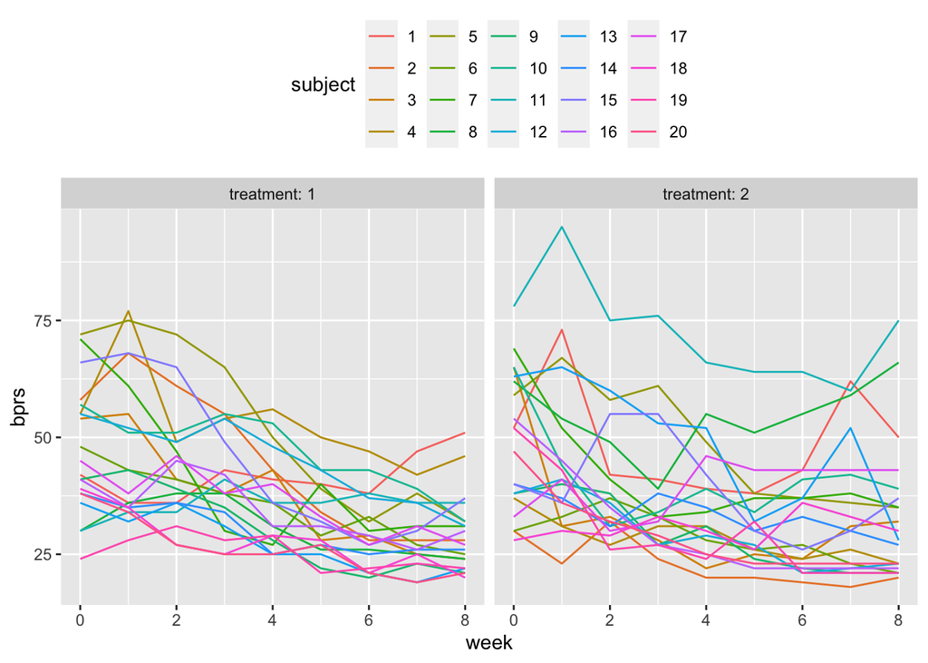

```r
# Plot the data
library(ggplot2)
ggplot(BPRS, aes(x = week, y = bprs, group = subject)) +
  geom_line(aes(col = subject)) +
  theme(legend.position = "top") +
  facet_grid(. ~ treatment, labeller = label_both)
```

Because the data in longitudinal, i.e., we expect the data points of individual subjects to have mutual dependencies, we can not fit a simple linear regression model to the data. The model experimented with here is the *Random Intercept model*. This model does not assume the repeated measures to be independent of each others, and thus allows us to fit a linear regression model for each individual so that the fit differs in intercept from the other individuals. However, let us first assess how a simple linear regression model fits to the data to obtain a baseline.

```r
# regression model
BPRS_reg <- lm(BPRS$bprs ~ BPRS$week + BPRS$treatment)

# summary of the model
summary(BPRS_reg)
```

```
##
## Call:
## lm(formula = BPRS$bprs ~ BPRS$week + BPRS$treatment)
##
## Residuals:
##     Min      1Q  Median      3Q     Max
## -22.454  -8.965  -3.196   7.002  50.244
##
## Coefficients:
##                 Estimate Std. Error t value Pr(>|t|)
## (Intercept)      46.4539     1.3670  33.982   <2e-16 ***
## BPRS$week        -2.2704     0.2524  -8.995   <2e-16 ***
## BPRS$treatment2   0.5722     1.3034   0.439    0.661
## ---
## Signif. codes:  0 '***' 0.001 '**' 0.01 '*' 0.05 '.' 0.1 ' ' 1
##
## Residual standard error: 12.37 on 357 degrees of freedom
## Multiple R-squared:  0.1851, Adjusted R-squared:  0.1806
## F-statistic: 40.55 on 2 and 357 DF,  p-value: < 2.2e-16
```

```r
# access library lme4
library(lme4)
# random intercept model
BPRS_ref <- lmer(bprs ~ week + treatment + (1 | subject), data = BPRS, REML = FALSE)

# summary of the model
summary(BPRS_ref)
```

```
## Linear mixed model fit by maximum likelihood  ['lmerMod']
## Formula: bprs ~ week + treatment + (1 | subject)
##    Data: BPRS
##
##      AIC      BIC   logLik deviance df.resid
##   2748.7   2768.1  -1369.4   2738.7      355
##
## Scaled residuals:
##     Min      1Q  Median      3Q     Max
## -3.0481 -0.6749 -0.1361  0.4813  3.4855
##
## Random effects:
##  Groups   Name        Variance Std.Dev.
##  subject  (Intercept)  47.41    6.885
##  Residual             104.21   10.208
## Number of obs: 360, groups:  subject, 20
##
## Fixed effects:
##             Estimate Std. Error t value
## (Intercept)  46.4539     1.9090  24.334
## week         -2.2704     0.2084 -10.896
## treatment2    0.5722     1.0761   0.532
##
## Correlation of Fixed Effects:
##            (Intr) week
## week       -0.437
## treatment2 -0.282  0.000
```

Based on the results of the fitted random intercept model above, the estimated variance of the subject random effects does not seem really large (47.41). This indicates that there is not so high variation between the intercepts of the regression fits between the individuals. Additionally, the estimated standard error of `week` is only slightly lower compared to the model that assumes independence between the variables. Based on this experiment, it does not seem that there is much difference between the models.

Next, I fit a *random intercept and slope* model that, in addition to allowing the regression model’s fit differ in intercept from the other individuals, it also allows the same for the slopes. Here, the estimated variance of the subject random effects is already considerably higher, indicating variation between the intercepts of the regression fits of the individuals. Standard error is slightly higher than earlier, though. Again, it does not seem that the difference between the models is really large.

```r
# random intercept and random slope model
library(lme4)
BPRS_ref1 <- lmer(bprs ~ week + treatment + (week | subject), data = BPRS, REML = FALSE)

# print a summary of the model
summary(BPRS_ref1)
```

```
## Linear mixed model fit by maximum likelihood  ['lmerMod']
## Formula: bprs ~ week + treatment + (week | subject)
##    Data: BPRS
##
##      AIC      BIC   logLik deviance df.resid
##   2745.4   2772.6  -1365.7   2731.4      353
##
## Scaled residuals:
##     Min      1Q  Median      3Q     Max
## -2.8919 -0.6194 -0.0691  0.5531  3.7976
##
## Random effects:
##  Groups   Name        Variance Std.Dev. Corr
##  subject  (Intercept) 64.8222  8.0512
##           week         0.9609  0.9802   -0.51
##  Residual             97.4305  9.8707
## Number of obs: 360, groups:  subject, 20
##
## Fixed effects:
##             Estimate Std. Error t value
## (Intercept)  46.4539     2.1052  22.066
## week         -2.2704     0.2977  -7.626
## treatment2    0.5722     1.0405   0.550
##
## Correlation of Fixed Effects:
##            (Intr) week
## week       -0.582
## treatment2 -0.247  0.000
```

As a next step, I perform the ANOVA test for the two random intercept models. From the Chi-squared test results below, we can read that the result is slightly significant (p = 0.026). Thus, we can reject the null hypothesis that the correlation between the random intercept and slope is 0.

```r
anova(BPRS_ref1, BPRS_ref)
```

```
## Data: BPRS
## Models:
## BPRS_ref: bprs ~ week + treatment + (1 | subject)
## BPRS_ref1: bprs ~ week + treatment + (week | subject)
##           npar    AIC    BIC  logLik deviance  Chisq Df Pr(>Chisq)
## BPRS_ref     5 2748.7 2768.1 -1369.4   2738.7
## BPRS_ref1    7 2745.4 2772.6 -1365.7   2731.4 7.2721  2    0.02636 *
## ---
## Signif. codes:  0 '***' 0.001 '**' 0.01 '*' 0.05 '.' 0.1 ' ' 1
```

Finally, we fit a random intercept and slope model with interaction between time and treatment. The visualizations in the end of this page suggest that the model fits the data well. However, looking at the results of the ANOVA below, it does not seem like the difference between the model with interaction and the model without it is significant (Chi-square, p = 0.075). To conclude, for the BPRS data, either random intecept and slope model is better than only a linear regression model, but it does not seem to matter much whether the random intercept and slope model includes interaction or not.

```r
# create a random intercept and random slope model with the interaction
library(lme4)
BPRS_ref2 <- lmer(bprs ~ week + treatment + (week | subject) + week * treatment, data = BPRS, REML = FALSE)

# print a summary of the model
summary(BPRS_ref2)
```

```
## Linear mixed model fit by maximum likelihood  ['lmerMod']
## Formula: bprs ~ week + treatment + (week | subject) + week * treatment
##    Data: BPRS
##
##      AIC      BIC   logLik deviance df.resid
##   2744.3   2775.4  -1364.1   2728.3      352
##
## Scaled residuals:
##     Min      1Q  Median      3Q     Max
## -3.0512 -0.6271 -0.0768  0.5288  3.9260
##
## Random effects:
##  Groups   Name        Variance Std.Dev. Corr
##  subject  (Intercept) 64.9964  8.0620
##           week         0.9687  0.9842   -0.51
##  Residual             96.4707  9.8220
## Number of obs: 360, groups:  subject, 20
##
## Fixed effects:
##                 Estimate Std. Error t value
## (Intercept)      47.8856     2.2521  21.262
## week             -2.6283     0.3589  -7.323
## treatment2       -2.2911     1.9090  -1.200
## week:treatment2   0.7158     0.4010   1.785
##
## Correlation of Fixed Effects:
##             (Intr) week   trtmn2
## week        -0.650
## treatment2  -0.424  0.469
## wek:trtmnt2  0.356 -0.559 -0.840
```

```r
# perform an ANOVA test on the two models
anova(BPRS_ref2, BPRS_ref1)
```

```
## Data: BPRS
## Models:
## BPRS_ref1: bprs ~ week + treatment + (week | subject)
## BPRS_ref2: bprs ~ week + treatment + (week | subject) + week * treatment
##           npar    AIC    BIC  logLik deviance  Chisq Df Pr(>Chisq)
## BPRS_ref1    7 2745.4 2772.6 -1365.7   2731.4
## BPRS_ref2    8 2744.3 2775.4 -1364.1   2728.3 3.1712  1    0.07495 .
## ---
## Signif. codes:  0 '***' 0.001 '**' 0.01 '*' 0.05 '.' 0.1 ' ' 1
```

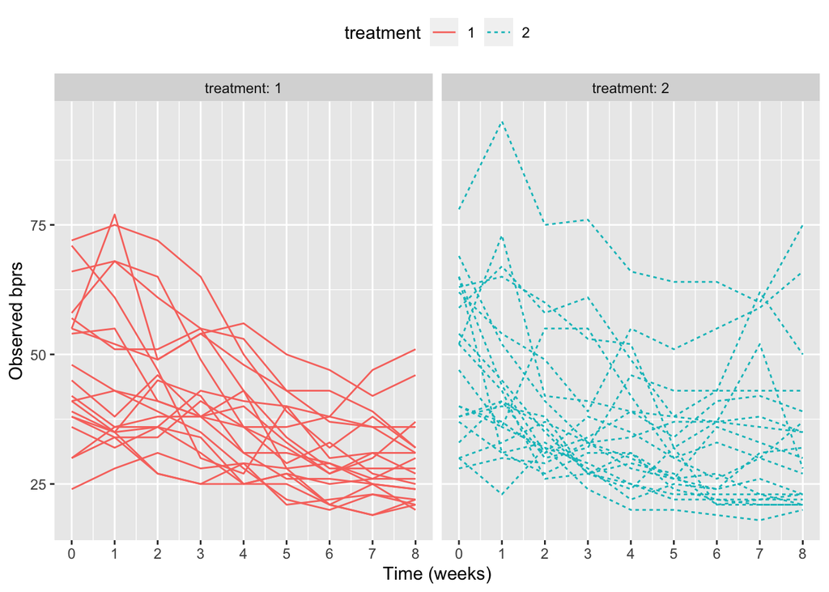

```r
# draw the plot of BPRS with the observed Weight values
library(ggplot2)
ggplot(BPRS, aes(x = week, y = bprs, group = subject)) +
  geom_line(aes(col = treatment, linetype = treatment)) +
  scale_x_continuous(name = "Time (weeks)", breaks = seq(0, 8, 1)) +
  scale_y_continuous(name = "Observed bprs") +
  theme(legend.position = "top") +
  facet_grid(. ~ treatment, labeller = label_both)
```

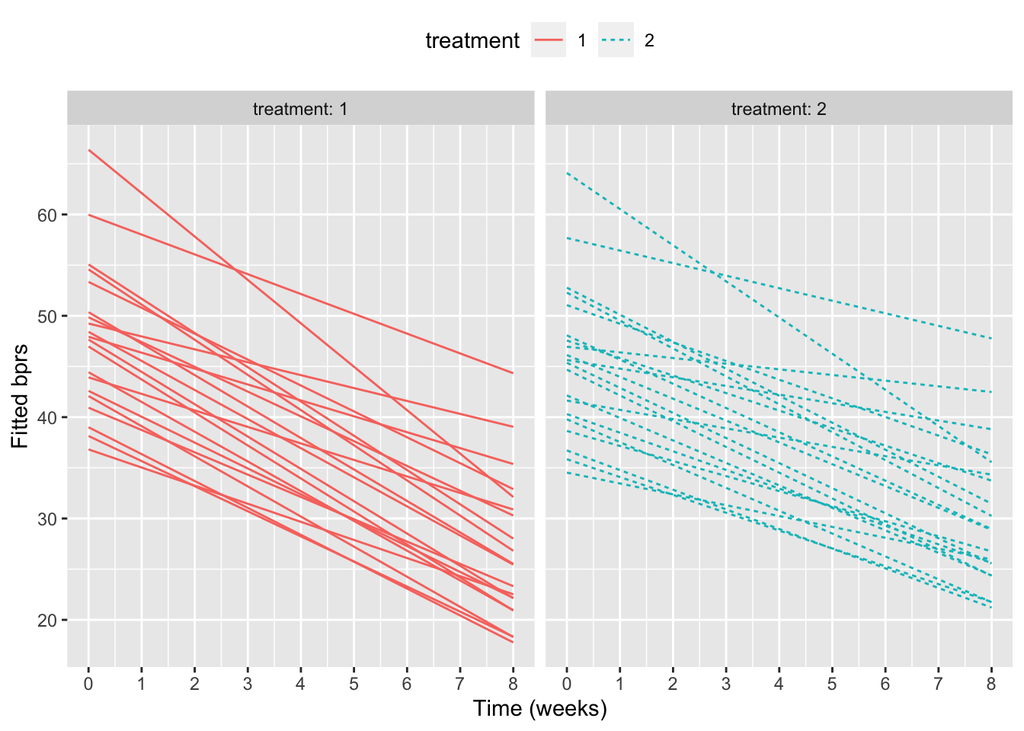

```r
# Create a vector of the fitted values
Fitted <- fitted(BPRS_ref2)

library(dplyr)
library(tidyr)
# Create a new column fitted to BPRS
BPRS <- BPRS %>%
  mutate(Fitted = Fitted)

# draw the plot of BPRS with the Fitted values of weight
library(ggplot2)
ggplot(BPRS, aes(x = week, y = Fitted, group = subject)) +
  geom_line(aes(col = treatment, linetype = treatment)) +
  scale_x_continuous(name = "Time (weeks)", breaks = seq(0, 8, 1)) +
  scale_y_continuous(name = "Fitted bprs") +
  theme(legend.position = "top") +
  facet_grid(. ~ treatment, labeller = label_both)
```